# Lab 5

Author

Camille Heathcock

**Portfolio Revisions: I have adjusted my YAML to create a more clear document, as well as created names for all code chunks**

**1. Reorder the box plots so the weights go in descending order**

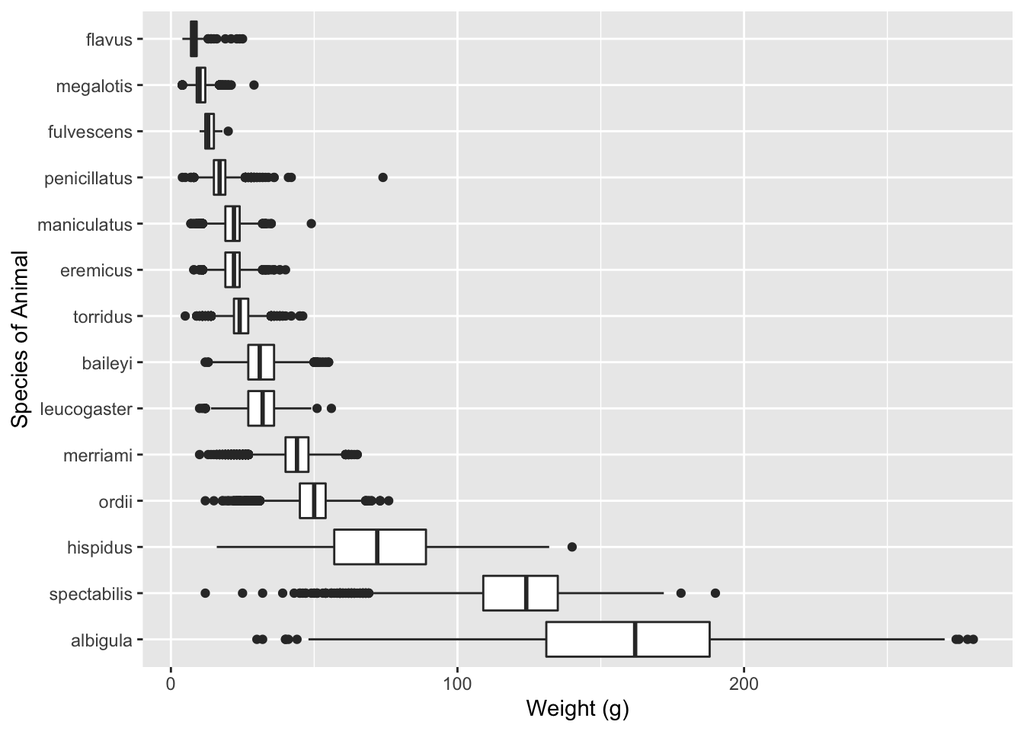

```r
#lab 2 plot
surveys |>
  ggplot(mapping = aes(y = fct_reorder(species,
                                       weight,
                                       .desc = TRUE),
                       x = weight)) +
  geom_boxplot() +
  labs(x = "Weight (g)",
       y = "Species of Animal")
```

**2. Now that you’ve reordered, look at your y-axis label. That’s long! Let’s take Will Chase’s advice and move the y-axis label to the top of the plot.**

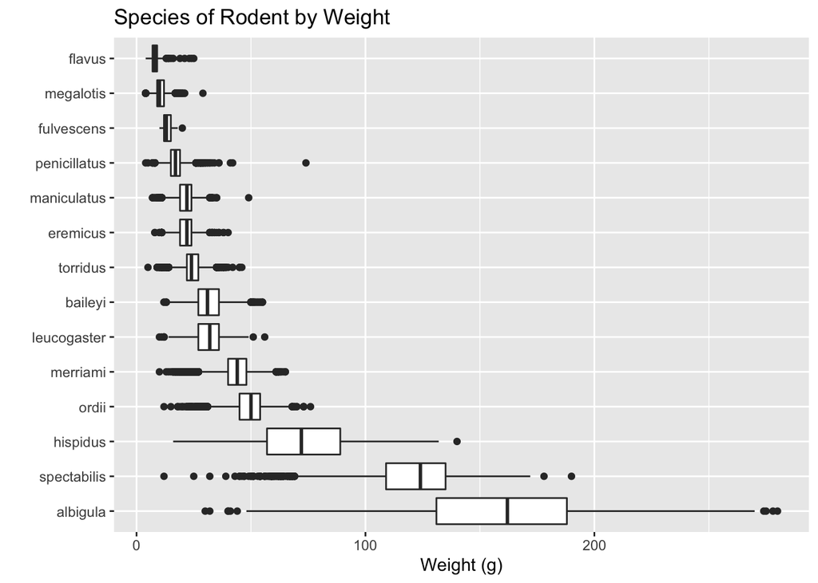

```r
surveys |>
  ggplot(mapping = aes(y = fct_reorder(species, weight, .desc = TRUE),
                       x = weight)) +
  geom_boxplot() +
  labs(x = "Weight (g)",
       y = " ") +
  ggtitle("Species of Rodent by Weight")
```

## Time Series Plot

**1. Create a visualization how weights vary for each genus over the duration of the study.**

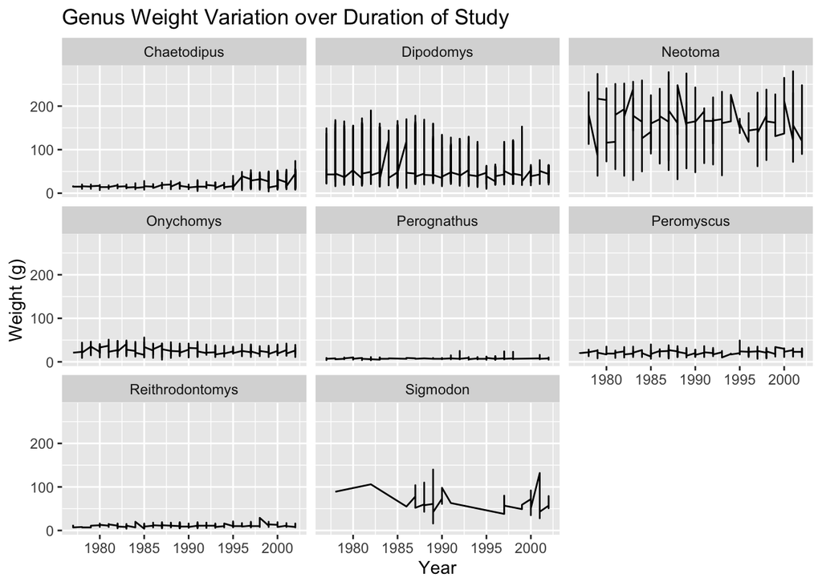

```r
surveys |>
  ggplot(aes(x = year,
             y = weight)) +
  geom_line() +
  facet_wrap( ~ genus) +
  labs(title = "Genus Weight Variation over Duration of Study",
       x = "Year",
       y = "Weight (g)")
```

**2. Calculate and plot the mean weight for each year (for each genus).**

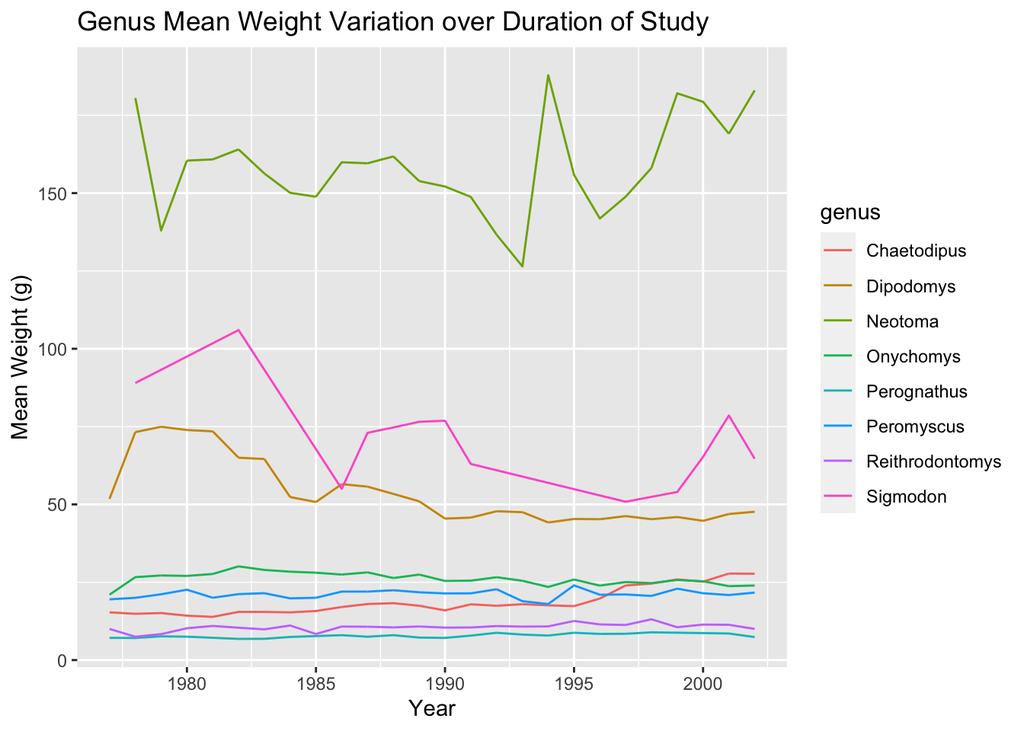

```r
mean_yearly_weight <- surveys |>
  group_by(year, genus) |>
  summarize(mean_weight = mean(weight))

surveys_exp <- full_join(surveys, mean_yearly_weight)

surveys_exp |>
  ggplot(aes(x = year,
             y = mean_weight,
             color = genus)) +
  geom_line() +
  labs(title = "Genus Mean Weight Variation over Duration of Study",
       x = "Year", y = "Mean Weight (g)")
```

**3. Reorder the lines so the weights go in descending order.**

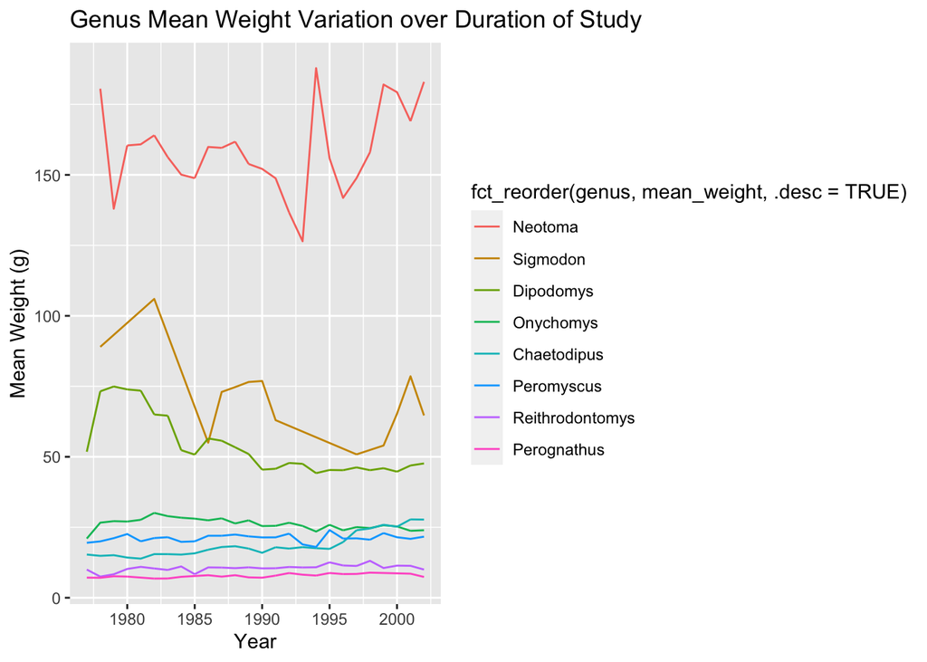

```r
surveys_exp |>
  ggplot(aes(x = year,
             y = mean_weight,
             color = fct_reorder(genus, mean_weight, .desc = TRUE))) +
  geom_line() +
  labs(title = "Genus Mean Weight Variation over Duration of Study",
       x = "Year",
       y = "Mean Weight (g)")
```

**4. Now that you’ve reordered the lines, look at your legend’s label. That’s terrible! Let’s give the legend a new title *and* move the information from the y-axis to the plot title.**

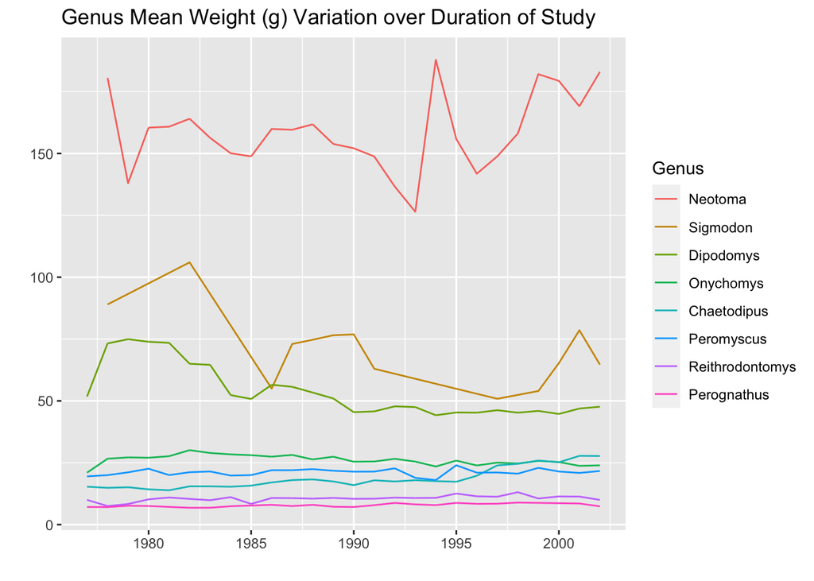

```r
surveys_exp |>
  ggplot(aes(x = year,
             y = mean_weight,
             color = fct_reorder(genus, mean_weight, .desc = TRUE))) +
  geom_line() +
  labs(title = "Genus Mean Weight (g) Variation over Duration of Study",
       x = "",
       y = "",
       color = "Genus")
```

## **Captures over the Week**

**1. Create a visualization of the number of rodents captured each day of the week.**

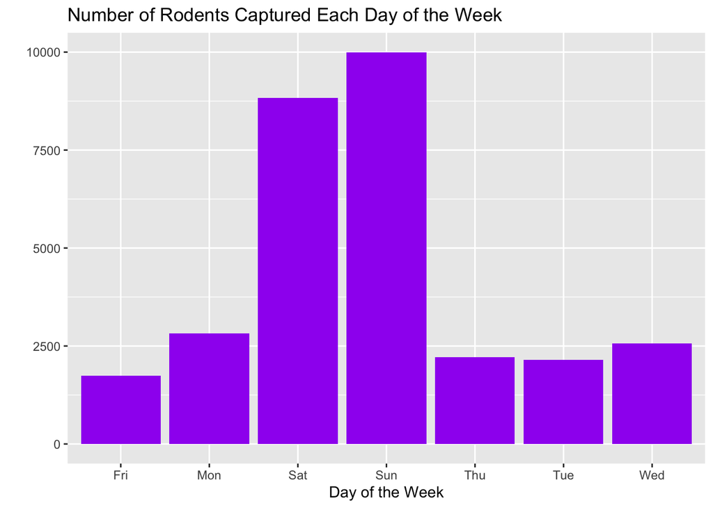

```r
surveys_daily <- surveys |>
  group_by(day_of_week) |>
  drop_na(day_of_week) |>
  count(day_of_week)

surveys |>
  drop_na(day_of_week) |>
  ggplot(mapping = aes(x = fct_relevel(day_of_week))) +
  geom_bar(fill = "purple") +
  labs(x = "Day of the Week",
       y = "",
       title = "Number of Rodents Captured Each Day of the Week")
```

**2. Change the order of the day of the week to go Monday through Sunday.**

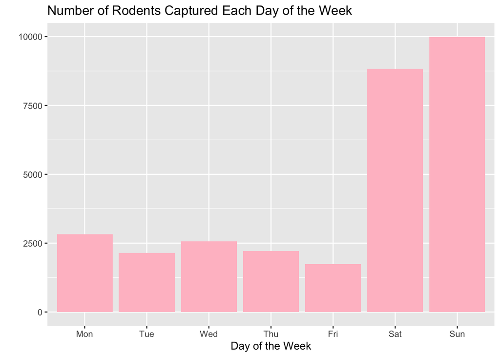

```r
surveys |>
  drop_na(day_of_week) |>
  ggplot(mapping = aes(x = fct_relevel(day_of_week,
                                     c("Mon",
                                       "Tue",
                                       "Wed",
                                       "Thu",
                                       "Fri",
                                       "Sat",
                                       "Sun")))) +
  geom_bar(fill = "pink") +
  labs(x = "Day of the Week",
       y = "",
       title = "Number of Rodents Captured Each Day of the Week")
```

**3. Collapse Monday through Friday into a `"Weekday"` level, and collapse Saturday and Sunday into a `"Weekend"` level. Plot the number of rodents captured between the two groups.**

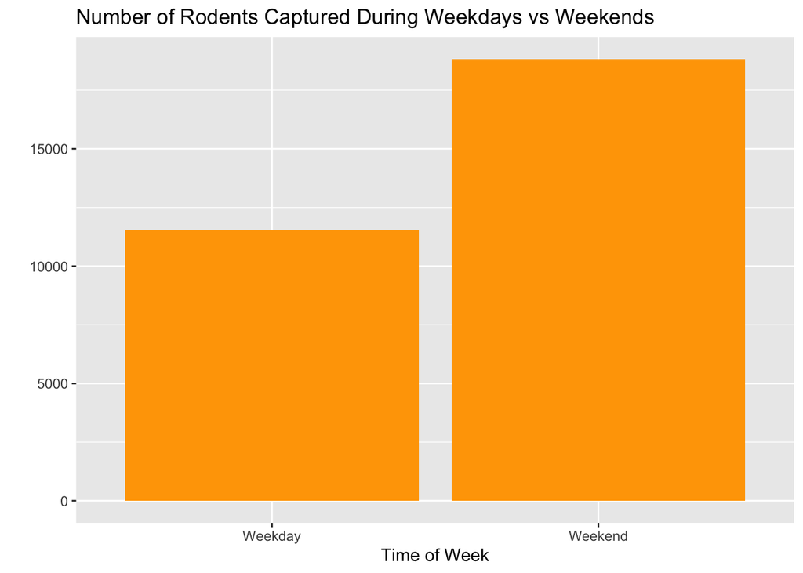

```r
surveys <- surveys |>
  drop_na(day_of_week) |>
  mutate(time_of_week = fct_collapse(day_of_week,
               Weekday = c("Mon", "Tue", "Wed", "Thu", "Fri"),
               Weekend = c("Sat", "Sun")))

ggplot(data = surveys, mapping = aes(x = time_of_week)) +
  geom_bar(fill = "orange") +
  labs(x = "Time of Week",
       y = "",
       title = "Number of Rodents Captured During Weekdays vs Weekends")
```